# Projekt Zaliczeniowy - SQL i Imputacje danych

Jakub Kur, Łukasz Szweda, Jula Bulińska

01 08 2021

Projekt zaliczoniowy wykonalismy wykorzystujac baze danych “Sakila”. To fikcyjna baza danych zaprojektowana do reprezentowania wypożyczalni DVD. Baza danych zostala oparta na SQL3Lite Projekt zostal podzielony na dwa etapy:  
w pierwszym wykorzystujemy SQL do stworzenia zapytan w celu wyciagniecia interesujacych nas informacji z bazy danych. W projekcie wykorzystalismy miedzy innymi takie funkcjonalnosci jak: filtrowanie; funkcje agregujace; sortowanie; laczenie danych.  
Dla powstalych zlaczonych tablic sprawdzilismy braki danych. Zbadalismy ich statystyki i rozklady. Nastepnie dokonalismy imputacji brakujacych danych i porównalismy nowo powstale rozklady i statystyki w celu zdefiniowania roznic.

```r
# Podlaczenie do bazy danych z pliku
con <- dbConnect(RSQLite::SQLite(), 'F:/SQL_TID Projekt/sqlite-sakila.db')
```

Dostepne tablice opracowywanej bazy danych zostały zaprezentowane w tablicy poniżej:

```sql
SELECT name
            FROM sqlite_master
            WHERE type ='table' AND name NOT LIKE 'sqlite_%';
```

Tablica 1 - Nazwy tablic w bazie danych `sqlite-sakila`

| name |
| --- |
| actor |
| country |
| city |
| address |
| language |
| category |
| customer |
| film |
| film_actor |
| film_category |
| film_text |
| inventory |
| staff |
| store |
| payment |
| rental |

Wysylajac ponizsze zapytanie mozna sprawdzic nazwy kolumn poszczegolnej tablicy z bazy danych:

```sql
SELECT name FROM PRAGMA_TABLE_INFO('actor')
```

4 records

| name |
| --- |
| actor_id |
| first_name |
| last_name |
| last_update |

Na podstawie dostepnych informacji z bazy danych stworzony zostal diagram polaczen miedzy tablicami, zaprezentowany ponizej. W dalszej czesci projektu posluzyl on jako pomoc w definiowaniu mozliwych polaczen pomiedzy tablicami i usprawnieniu pracy.

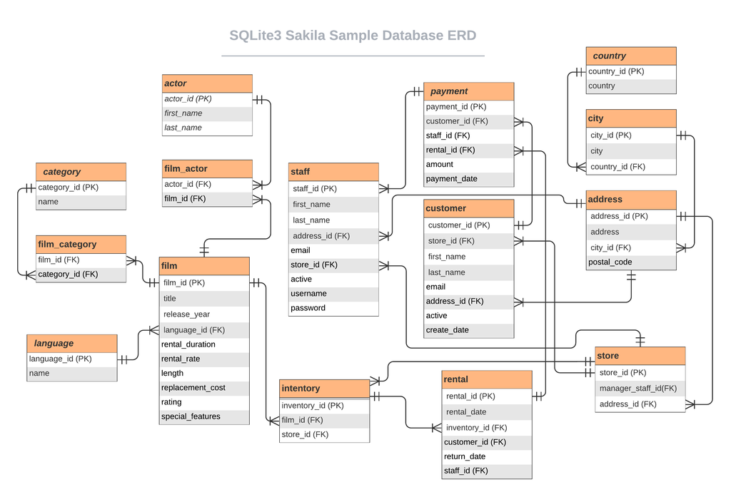

```r
#dbSendQuery - funkcja z pakietu DBI pozwalajaca na tworzenie zapytan SQL w srodowisku R
for (i in 1:nrow(table_names)){
  colnames = dbSendQuery(con,
            paste0("SELECT name FROM PRAGMA_TABLE_INFO('",table_names[i,1],"')"))
  colnames = dbFetch(colnames)
  colnames(colnames) = table_names[i,1]
  assign(x = table_names[i,1],
         value = colnames)
}
table_colnames = data.frame(do.call(rbind, Map(cbind, Tablica = names(c(actor,address,category,city,country,customer,film,film_actor,film_category,film_text,inventory,language,payment,rental,staff,store)), Kolumna = c(actor,address,category,city,country,customer,film,film_actor,film_category,film_text,inventory,language,payment,rental,staff,store))))
#Network plot
p <- simpleNetwork(table_colnames, height="100px", width="100px",
        linkDistance = 10,          # distance between node. Increase this value to have more space between nodes
        charge = -900,                # numeric value indicating either the strength of the node repulsion (negative value) or attraction (positive value)
        fontSize = 14,               # size of the node names
        fontFamily = "serif",       # font og node names
        linkColour = "#666",        # colour of edges, MUST be a common colour for the whole graph
        nodeColour = "red",     # colour of nodes, MUST be a common colour for the whole graph
        opacity = 0.9,              # opacity of nodes. 0=transparent. 1=no transparency
        zoom = T                    # Can you zoom on the figure?
        )
p
```

[interactive chart not shown]

Podstawowe zapytanie SQL - imiona i nazwiska 8 osob z tablicy *actor*.

```sql
SELECT DISTINCT actor.first_name AS Imie, actor.last_name AS Nazwisko
FROM actor
LIMIT 8
```

8 records

| Imie | Nazwisko |
| --- | --- |
| PENELOPE | GUINESS |
| NICK | WAHLBERG |
| ED | CHASE |
| JENNIFER | DAVIS |
| JOHNNY | LOLLOBRIGIDA |
| BETTE | NICHOLSON |
| GRACE | MOSTEL |
| MATTHEW | JOHANSSON |

Top 10 aktorow wystepujacych w najwiekszej ilosci filmow:

```sql
SELECT film_actor.actor_id AS ID, actor.first_name AS Imie, actor.last_name AS Nazwisko, COUNT(film_actor.actor_id) AS Liczba_filmow
                   FROM actor
                   INNER JOIN film_actor ON film_actor.actor_id=actor.actor_id
                   GROUP BY film_actor.actor_id
                   ORDER BY liczba_filmow DESC
                   LIMIT 10
```

Displaying records 1 - 10

| ID | Imie | Nazwisko | Liczba_filmow |
| --- | --- | --- | --- |
| 107 | GINA | DEGENERES | 42 |
| 102 | WALTER | TORN | 41 |
| 198 | MARY | KEITEL | 40 |
| 181 | MATTHEW | CARREY | 39 |
| 23 | SANDRA | KILMER | 37 |
| 81 | SCARLETT | DAMON | 36 |
| 13 | UMA | WOOD | 35 |
| 37 | VAL | BOLGER | 35 |
| 60 | HENRY | BERRY | 35 |
| 106 | GROUCHO | DUNST | 35 |

Sredni czas trwania wypozyczenia filmow przez klientow (w dniach):

```sql
SELECT AVG(rental_duration) AS sredni_czas
                  FROM film
```

1 records

| sredni_czas |
| --- |
| 4.985 |

Liczba filmow w bazie ktore sa przeznaczone dla doroslych (na podstawie MPA film ratings - G, G, PG-13, R, NC-17):

```sql
SELECT COUNT(rating) AS filmy_dla_doroslych
                  FROM film
                   WHERE rating='NC-17'
```

1 records

| filmy_dla_doroslych |
| --- |
| 210 |

Typy filmow wedlug metrazu (pelnometrazowy, sredniometrazowy, krotkometrazowy) (wyszukanie ograniczone do 10 pierwszych, lacznie dostepnych 1000)

```sql
SELECT film_id, title AS tytul, length AS dlugosc, CASE
                   WHEN length > 70 THEN 'pelnometrazowy'
                   WHEN length < 30 THEN 'krotkometrazowy'
                   ELSE 'sredniometrazowy'
                   END as 'metraz filmu'
                   FROM film
                   LIMIT 10
```

Displaying records 1 - 10

| film_id | tytul | dlugosc | metraz filmu |
| --- | --- | --- | --- |
| 1 | ACADEMY DINOSAUR | 86 | pelnometrazowy |
| 2 | ACE GOLDFINGER | 48 | sredniometrazowy |
| 3 | ADAPTATION HOLES | 50 | sredniometrazowy |
| 4 | AFFAIR PREJUDICE | 117 | pelnometrazowy |
| 5 | AFRICAN EGG | 130 | pelnometrazowy |
| 6 | AGENT TRUMAN | 169 | pelnometrazowy |
| 7 | AIRPLANE SIERRA | 62 | sredniometrazowy |
| 8 | AIRPORT POLLOCK | 54 | sredniometrazowy |
| 9 | ALABAMA DEVIL | 114 | pelnometrazowy |
| 10 | ALADDIN CALENDAR | 63 | sredniometrazowy |

Top 5 najczesciej wypozyczanych filmow

```sql
SELECT inventory.film_id, film.title AS tytul, COUNT(rental.inventory_id) AS ilosc_wypozyczen
                   FROM film
                   INNER JOIN inventory on film.film_id=inventory.film_id
                   INNER JOIN rental on rental.inventory_id=inventory.inventory_id
                   GROUP BY film.title
                   ORDER BY ilosc_wypozyczen DESC
                   LIMIT 5
```

5 records

| film_id | tytul | ilosc_wypozyczen |
| --- | --- | --- |
| 103 | BUCKET BROTHERHOOD | 34 |
| 738 | ROCKETEER MOTHER | 33 |
| 767 | SCALAWAG DUCK | 32 |
| 730 | RIDGEMONT SUBMARINE | 32 |
| 489 | JUGGLER HARDLY | 32 |

```sql
SELECT substr(payment_date, 6, 2) AS miesiac, SUM(amount) AS sprzedaz
                   FROM payment
                   GROUP BY miesiac
                   ORDER BY miesiac DESC
```

5 records

| miesiac | sprzedaz |
| --- | --- |
| 08 | 24072.13 |
| 07 | 28373.89 |
| 06 | 9631.88 |
| 05 | 4824.43 |
| 02 | 514.18 |

```sql
SELECT SUM(amount)
                   FROM payment
                   WHERE payment_date LIKE '2005-07%'
```

1 records

| SUM(amount) |
| --- |
| 28373.89 |

Kraje, z ktorych glownie pochodzi wypozyczajacy

```sql
SELECT country.country AS Kraj, COUNT(country.country) AS Liczba_klientow
                   FROM customer
                   INNER JOIN address on customer.address_id=address.address_id
                   INNER JOIN city on address.city_id=city.city_id
                   INNER JOIN country on city.country_id=country.country_id
                   GROUP BY kraj
                   ORDER BY liczba_klientow DESC
                   LIMIT 40
```

Displaying records 1 - 10

| Kraj | Liczba_klientow |
| --- | --- |
| India | 60 |
| China | 53 |
| United States | 36 |
| Japan | 31 |
| Mexico | 30 |
| Russian Federation | 28 |
| Brazil | 28 |
| Philippines | 20 |
| Turkey | 15 |
| Indonesia | 14 |

Klienci, ktorzy zaplacili 0$

```sql
SELECT customer.customer_id, customer.first_name, customer.last_name, payment.amount
                   FROM customer
                   LEFT JOIN payment ON customer.customer_id=payment.customer_id
                   WHERE payment.amount=0
```

Displaying records 1 - 10

| customer_id | first_name | last_name | amount |
| --- | --- | --- | --- |
| 15 | HELEN | HARRIS | 0 |
| 42 | CAROLYN | PEREZ | 0 |
| 43 | CHRISTINE | ROBERTS | 0 |
| 53 | HEATHER | MORRIS | 0 |
| 60 | MILDRED | BAILEY | 0 |
| 75 | TAMMY | SANDERS | 0 |
| 75 | TAMMY | SANDERS | 0 |
| 107 | FLORENCE | WOODS | 0 |
| 155 | GAIL | KNIGHT | 0 |
| 163 | CATHY | SPENCER | 0 |

Ilosc jezyków filmow( wszystkie filmy w bazie sa w jezyku angielskim)

```sql
SELECT language.name, COUNT(language.name) AS Sumy_jezykow_filmow
FROM film
LEFT JOIN language ON film.language_id=language.language_id
```

1 records

| name | Sumy_jezykow_filmow |
| --- | --- |
| English | 1000 |

Popularnosc ogladanych aktorow (na podstawie sredniej dlugosci najmu i sredniej oceny najmu)(top20)

```sql
SELECT actor.first_name, actor.last_name, avg(rental_duration) as popularnosc_dlugosc_sr, avg(rental_rate) as popularnosc_ocena_sr
from film_actor
LEFT JOIN actor ON film_actor.actor_id=actor.actor_id
LEFT JOIN film ON film_actor.film_id=film.film_id
GROUP BY actor.last_name
ORDER BY popularnosc_dlugosc_sr desc
LIMIT 20
```

Displaying records 1 - 10

| first_name | last_name | popularnosc_dlugosc_sr | popularnosc_ocena_sr |
| --- | --- | --- | --- |
| NICK | STALLONE | 5.500000 | 2.856667 |
| LIZA | BERGMAN | 5.440000 | 3.550000 |
| KIRK | JOVOVICH | 5.423077 | 2.759231 |
| LUCILLE | DEE | 5.421053 | 3.358421 |
| ANGELA | HUDSON | 5.382353 | 2.990000 |
| MARY | TANDY | 5.370968 | 2.893226 |
| OLYMPIA | PFEIFFER | 5.321429 | 2.918571 |
| WARREN | JACKMAN | 5.315790 | 2.849649 |
| CARMEN | HUNT | 5.307692 | 2.836154 |
| HARRISON | BALE | 5.285714 | 3.490000 |

Rodzaje kategorii

```sql
SELECT DISTINCT name
FROM category
```

Displaying records 1 - 10

| name |
| --- |
| Action |
| Animation |
| Children |
| Classics |
| Comedy |
| Documentary |
| Drama |
| Family |
| Foreign |
| Games |

Ilosc filmow wedlug kategorii

```sql
SELECT distinct category.name, count(category.name) as ilosc_wg_kat
FROM film
INNER JOIN film_category ON film.film_id=film_category.film_id
INNER JOIN category ON film_category.category_id=category.category_id
GROUP BY category.name
ORDER BY ilosc_wg_kat desc
```

Displaying records 1 - 10

| name | ilosc_wg_kat |
| --- | --- |
| Sports | 74 |
| Foreign | 73 |
| Family | 69 |
| Documentary | 68 |
| Animation | 66 |
| Action | 64 |
| New | 63 |
| Drama | 62 |
| Sci-Fi | 61 |
| Games | 61 |

Srednia dlugosc wynajmu wg kategorii

```sql
SELECT distinct category.name, avg(rental_duration) AS rental_dur
FROM film
INNER JOIN film_category ON film.film_id=film_category.film_id
INNER JOIN category ON film_category.category_id=category.category_id
GROUP BY category.name
ORDER BY rental_dur DESC
```

Displaying records 1 - 10

| name | rental_dur |
| --- | --- |
| Travel | 5.350877 |
| Music | 5.235294 |
| Family | 5.173913 |
| Foreign | 5.109589 |
| Drama | 5.080645 |
| Classics | 5.070175 |
| Games | 5.065574 |
| Children | 5.033333 |
| Action | 4.953125 |
| Comedy | 4.931034 |

Srednia ocena najmu wg kategorii

```sql
SELECT distinct category.name, avg(rental_rate) AS rental_rate
FROM film
INNER JOIN film_category ON film.film_id=film_category.film_id
INNER JOIN category ON film_category.category_id=category.category_id
GROUP BY category.name
ORDER BY rental_rate DESC
```

Displaying records 1 - 10

| name | rental_rate |
| --- | --- |
| Games | 3.252295 |
| Travel | 3.235614 |
| Sci-Fi | 3.219508 |
| Comedy | 3.162414 |
| Sports | 3.125135 |
| New | 3.116984 |
| Foreign | 3.099589 |
| Horror | 3.025714 |
| Drama | 3.022258 |
| Music | 2.950784 |

```sql
SELECT
    actor.first_name || ' ' || actor.last_name AS Name, COUNT(film.title) AS ilsc_wystapien_w_filmach
FROM film_actor
JOIN film
ON film_actor.film_id = film.film_id
JOIN actor
ON film_actor.actor_id = actor.actor_id
GROUP BY film.title
ORDER BY ilsc_wystapien_w_filmach DESC
limit 15
```

Displaying records 1 - 10

| Name | ilsc_wystapien_w_filmach |
| --- | --- |
| WOODY HOFFMAN | 15 |
| JENNIFER DAVIS | 13 |
| HELEN VOIGHT | 13 |
| NICK WAHLBERG | 13 |
| SISSY SOBIESKI | 13 |
| JOHNNY LOLLOBRIGIDA | 13 |
| ED CHASE | 13 |
| BETTE NICHOLSON | 12 |
| ELVIS MARX | 12 |
| RIP CRAWFORD | 12 |

Baza nieaktywnych klientow i ich adresy mailowe:

```sql
SELECT c.first_name, c.last_name, c.email, CASE
WHEN active=0 THEN 'nieaktywny'
END AS aktywnosc
FROM customer AS c
WHERE active=0
```

Displaying records 1 - 10

| first_name | last_name | email | aktywnosc |
| --- | --- | --- | --- |
| SANDRA | MARTIN | SANDRA.MARTIN@sakilacustomer.org | nieaktywny |
| JUDITH | COX | JUDITH.COX@sakilacustomer.org | nieaktywny |
| SHEILA | WELLS | SHEILA.WELLS@sakilacustomer.org | nieaktywny |
| ERICA | MATTHEWS | ERICA.MATTHEWS@sakilacustomer.org | nieaktywny |
| HEIDI | LARSON | HEIDI.LARSON@sakilacustomer.org | nieaktywny |
| PENNY | NEAL | PENNY.NEAL@sakilacustomer.org | nieaktywny |
| KENNETH | GOODEN | KENNETH.GOODEN@sakilacustomer.org | nieaktywny |
| HARRY | ARCE | HARRY.ARCE@sakilacustomer.org | nieaktywny |
| NATHAN | RUNYON | NATHAN.RUNYON@sakilacustomer.org | nieaktywny |
| THEODORE | CULP | THEODORE.CULP@sakilacustomer.org | nieaktywny |

Ilosc klientow

```sql
SELECT distinct COUNT(customer_id)
from customer
```

1 records

| COUNT(customer_id) |
| --- |
| 599 |

```sql
SELECT c1.city, count(c1.city)
FROM customer as c
JOIN address as a
ON c.address_id=a.address_id
JOIN city as c1
ON a.city_id=c1.city_id
```

1 records

| city | count(c1.city) |
| --- | --- |
| Sasebo | 599 |

srednia/max/min/ilosc/suma platnosci przyjetej przez pracownika z jego adresem sklepu

```sql
SELECT s.first_name, s.last_name,a.address || ' - '  || city as adres_sklepu, avg(p.amount) as sr_kwota ,max(p.amount) as max_kwota ,min(p.amount) as min_kwota, count(p.amount) as ilosc_platnosci, sum(p.amount) as suma_platnosci
FROM staff as s
JOIN payment as p
ON s.staff_id=p.staff_id
JOIN store as s1
ON s.store_id=s1.store_id
JOIN address as a
ON s1.address_id=a.address_id
JOIN city as c
ON a.city_id=c.city_id
group by s.last_name
```

2 records

| first_name | last_name | adres_sklepu | sr_kwota | max_kwota | min_kwota | ilosc_platnosci | suma_platnosci |
| --- | --- | --- | --- | --- | --- | --- | --- |
| Mike | Hillyer | 47 MySakila Drive - Lethbridge | 4.156568 | 11.99 | 0 | 8057 | 33489.47 |
| Jon | Stephens | 28 MySQL Boulevard - Woodridge | 4.245125 | 11.99 | 0 | 7992 | 33927.04 |

```sql
SELECT first_name, last_name, SUM(p.amount) as payment_sum, address
FROM customer as c
JOIN payment as p
ON c.customer_id=p.payment_id
JOIN store as s
ON c.store_id=s.store_id
JOIN address as a
ON s.address_id=a.address_id
WHERE active= 1
GROUP BY c.customer_id
ORDER BY payment_sum DESC
LIMIT 15
```

Displaying records 1 - 10

| first_name | last_name | payment_sum | address |
| --- | --- | --- | --- |
| HAROLD | MARTINO | 11.99 | 47 MySakila Drive |
| MARIE | TURNER | 10.99 | 47 MySakila Drive |
| JUDY | GRAY | 10.99 | 28 MySQL Boulevard |
| GARY | COY | 10.99 | 28 MySQL Boulevard |
| CLAYTON | BARBEE | 10.99 | 28 MySQL Boulevard |
| ELIZABETH | BROWN | 9.99 | 47 MySakila Drive |
| RHONDA | KENNEDY | 9.99 | 28 MySQL Boulevard |
| PEARL | GARZA | 9.99 | 28 MySQL Boulevard |
| MISTY | LAMBERT | 9.99 | 28 MySQL Boulevard |
| DOUGLAS | GRAF | 9.99 | 47 MySakila Drive |

Liczba filmow w ktorej dostepnych w sklepie w ktorej bral udzial dany aktor (20 pierwszych)

```sql
SELECT first_name, last_name, COUNT(f.title) as liczba_tytulow
FROM actor as a
JOIN film_actor AS fa
ON a.actor_id=fa.actor_id
JOIN film as f
ON fa.film_id=f.film_id
GROUP BY fa.actor_id
ORDER BY liczba_tytulow DESC
LIMIT 20
```

Displaying records 1 - 10

| first_name | last_name | liczba_tytulow |
| --- | --- | --- |
| GINA | DEGENERES | 42 |
| WALTER | TORN | 41 |
| MARY | KEITEL | 40 |
| MATTHEW | CARREY | 39 |
| SANDRA | KILMER | 37 |
| SCARLETT | DAMON | 36 |
| UMA | WOOD | 35 |
| VAL | BOLGER | 35 |
| HENRY | BERRY | 35 |
| GROUCHO | DUNST | 35 |